# Bayesian data analysis demos 11.3, and 11.4

Aki Vehtari, Markus Paasiniemi

2022-08-29

## Metropolis algorithm + Rhat (PSRF) demonstration

ggplot2 and gridExtra are used for plotting, tidyr for manipulating data frames

```r
library(ggplot2)
theme_set(theme_minimal())
library(gridExtra)
library(tidyverse)
library(gganimate)
library(MASS)
library(rstan)
library(rprojroot)
root<-has_file(".BDA_R_demos_root")$make_fix_file()
```

Parameters of a Normal distribution used as a toy target distribution

```r
y1 <- 0
y2 <- 0
r <- 0.8
S <- diag(2)
S[1, 2] <- r
S[2, 1] <- r
```

Sample from the toy distribution to visualize 90% HPD interval with ggplot’s stat_ellipse()

```r
dft <- data.frame(mvrnorm(100000, c(0, 0), S))
```

### Load pre-run Metropolis chains.

Since, implementation of the Metropolis algorithm is one of the exercises, we load here pre-computed chains and Rhat-values

The proposal distribution was intentionally selected to be slightly too small, to better illustrate convergence diagonstics

`tts' contains draws,`p1’ and ‘p2’ contain Rhat values for t1 and t2 using 50% warm-up, `pp1’ and ‘pp2’ contain Rhat values for t1 and t2 using 10% warm-up, Rhat-values have been computed for each time-step.

```r
load(root("demos_ch11","demo11_4.RData"))
```

Transform the first s1 rows of the data into a ‘tidy’ format for plotting

```r
s1 <- 50
dfs1 <- data.frame(iter = 1:s1, tts[1:s1, 1, ]) %>%
  gather(chain, th1, -iter) %>%
  within({th2 <- c(tts[1:s1, 2, ])         # xl and yl specify the previous
          th2l <- c(th2[1], th2[-length(th2)])   # draw in the chain for
          th1l <- c(th1[1], th1[-length(th1)])}) # plotting
```

Fix the incorrect lagged values, the lagged value of the first draw in the chain (for plotting) is the value itself (instead of the last value of the previous chain)

```r
sind <- 0:9*s1+1
dfs1[sind, c('th1l','th2l')] <- dfs1[sind, c('th1','th2')]
```

Another data frame with all draws

```r
inds2 <- 1:10000
dfs2 <- data.frame(iter = inds2, tts[inds2, 1, ]) %>%
  gather(chain, theta1, -iter) %>%
  within(theta2 <- c(tts[inds2, 2, ])) %>%
  gather(var, val, -iter, -chain)
```

Third data frame with Rhat values

```r
indsp <- seq(10, length(p1), 10)
dfp <- data.frame(iter = indsp,
                  theta1 = p1[indsp],
                  theta2 = p2[indsp]) %>%
  gather(var,rhat,-iter)
```

Construct a 2d-plot of the 50 first iterations of the chains

```r
frame = rep(1:s1, 10)
chains1 <- ggplot(data = dfs1) +
  geom_segment(aes(x = th1, xend = th1l, y = th2, yend = th2l, color = chain,
                   group = chain)) +
  geom_point(data = dfs1[sind, ], aes(x = th1, y = th2, color = chain)) +
  stat_ellipse(data = dft, aes(x = X1, y = X2), level = 0.9, color = 'black') +
  coord_cartesian(xlim = c(-4, 4), ylim = c(-4, 4)) +
  labs(x = 'theta1', y = 'theta2') +
  scale_color_discrete(guide = "none")
```

Animate s1 first iterations of the chains. At some points some of the chains seem to halt for

```r
#  a moment. What really happens at that point is that
```

they draw possibly a few points that are rejected (rejected points not shown) and thus the chain is not moving

```r
anim <- animate(chains1 +
                  transition_reveal(along=iter) +
                  shadow_trail(1/s1))
```

Show the animation

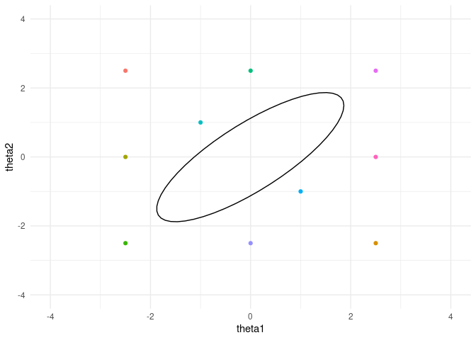

```r
anim
```

Plot the result, no convergence yet

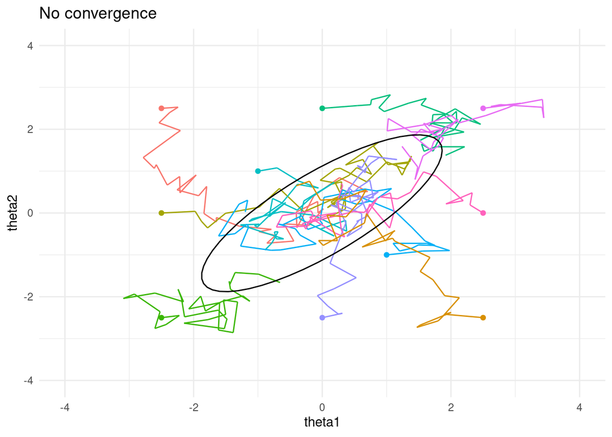

```r
chains1 + labs(title = 'No convergence')
```

Plot trends of the 50 first iterations

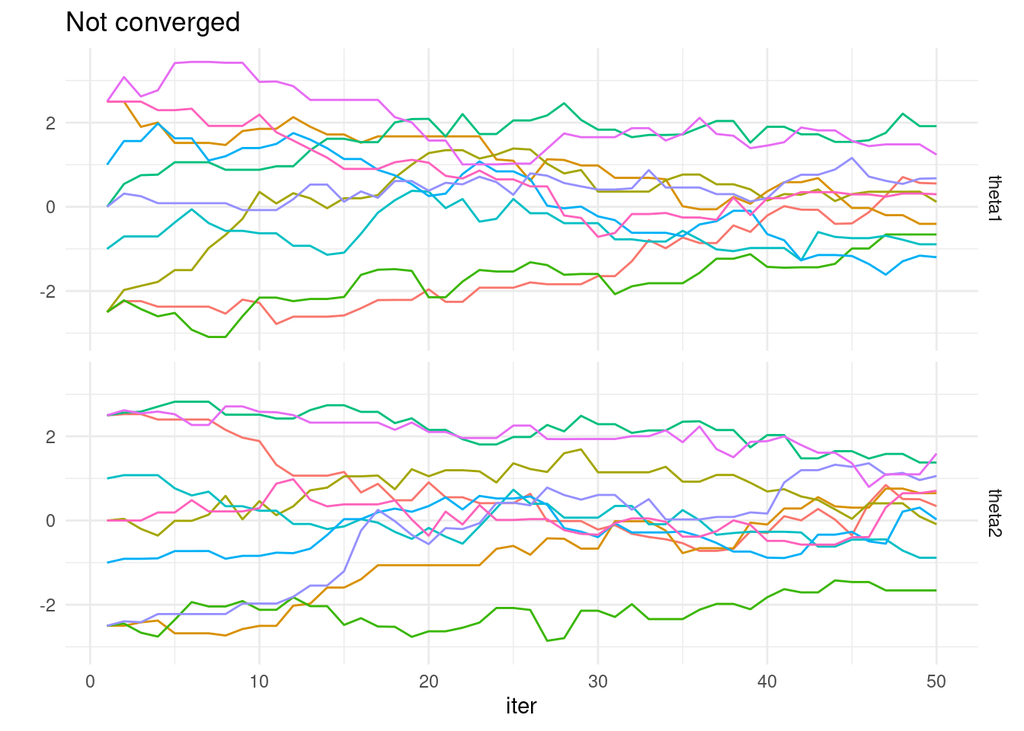

```r
ggplot(data = filter(dfs2, iter<=50)) +
  geom_line(aes(iter, val, color = chain)) +
  facet_grid(var~.) +
  labs(title = 'Not converged', y = '') +
  scale_color_discrete(guide = "none")
```

Plot trends of the all draws

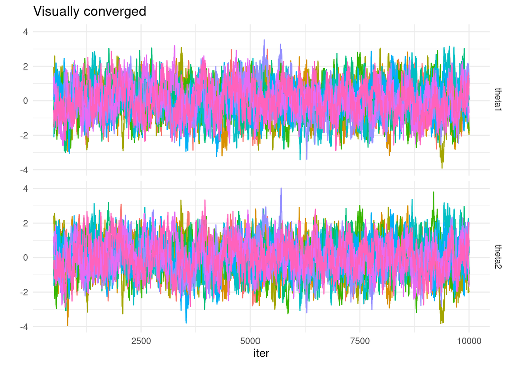

```r
ggplot(data = filter(dfs2, iter>500)) +
  geom_line(aes(iter, val, color = chain)) +
  facet_grid(var~.) +
  labs(title = 'Visually converged', y = '') +
  scale_color_discrete(guide = "none")
```

Function for plotting components of Rhat

```r
plotRhatcomps <- function(df = NULL, niter = NULL) {
  msdf <- df %>% filter(var=='theta1', iter<niter, iter>=niter/2) %>%
    group_by(chain) %>%
    summarise(mean=mean(val), sd=sd(val))
  ndf <-  msdf %>%
    pmap_df(~ data_frame(x = seq(-4, 4, length.out = 201), chain=..1,
                           density = dnorm(x, ..2, ..3)))
  # plot normal distribution approaximation for each chain to illustrate
  # means and variances
  p1 <- ggplot(ndf, aes(group = chain, x = x, y = density)) +
    geom_line(linetype=1, color="blue") +
    labs(x='theta1', y='',
       title=paste(niter/2, ' warmup, ', niter/2, 'post warmup iterations')) +
    scale_y_continuous(breaks=NULL)
  # compute Rhat
  n <- niter/2
  B <- n*var(msdf$mean)
  W <- mean(msdf$sd^2)
  varp <- (n-1)/n*W + B/n
  Rhat <- sqrt(varp/W)
  # plot normal approximations to illustrate W, marginal variance estimate
  # using within variances, and var_hat_plus, marginal variance estimate
  # combining W and between chain variance estimate

  p2 <- ggplot(data.frame(x=c(-4, 4)), aes(x)) +
    stat_function(fun = dnorm, args = list(mean=0, sd=sqrt(varp)), color='red') +
    stat_function(fun = dnorm, args = list(mean=0, sd=sqrt(W)), color='blue',
                  linetype=2) +
    scale_y_continuous(breaks=NULL) +
    labs(x = 'theta1', y='', title = paste('Rhat = ', round(Rhat,2))) +
    annotate('text', x= 0, y = 0.1, label = paste('var_hat_plus = ', round(varp,2)), color='red') +
    annotate('text', x= 0, y = 0.2, label = paste('W = ', round(W,2)), color='blue')
  grid.arrange(p1, p2)
}
```

Plot normal approximation of each chain and Rhat components with niter = 100, 1000, 10000 with 50% warmup

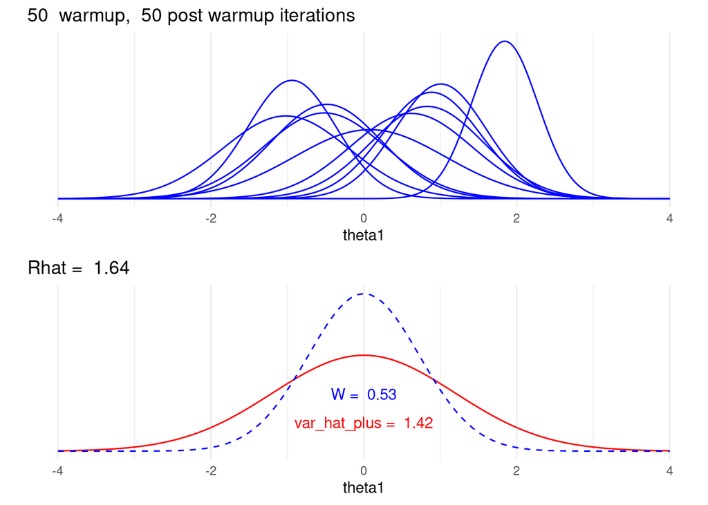

```r
niter <- 100
plotRhatcomps(dfs2, niter)
```

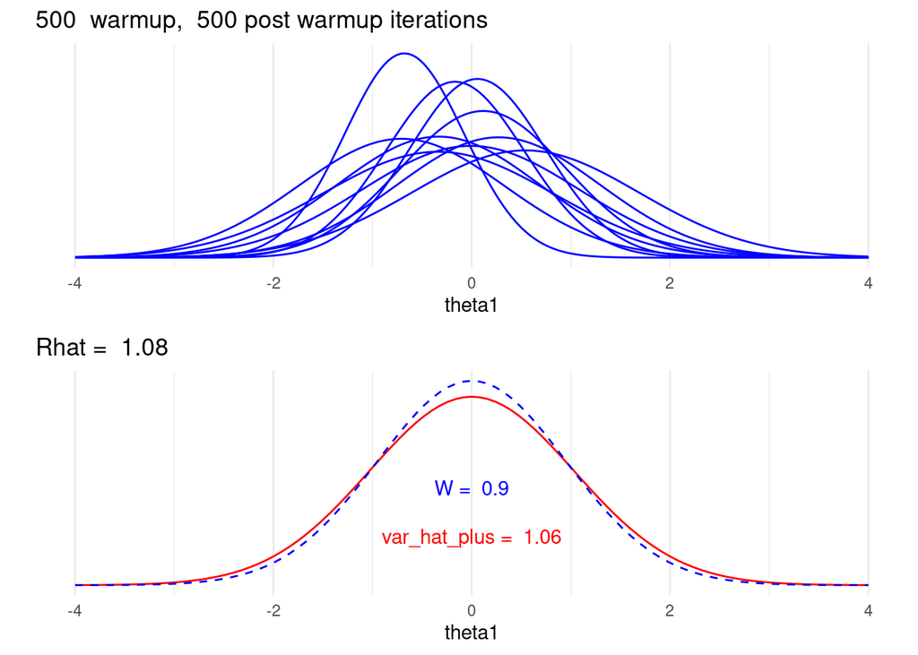

```r
niter <- 1000
plotRhatcomps(dfs2, niter)
```

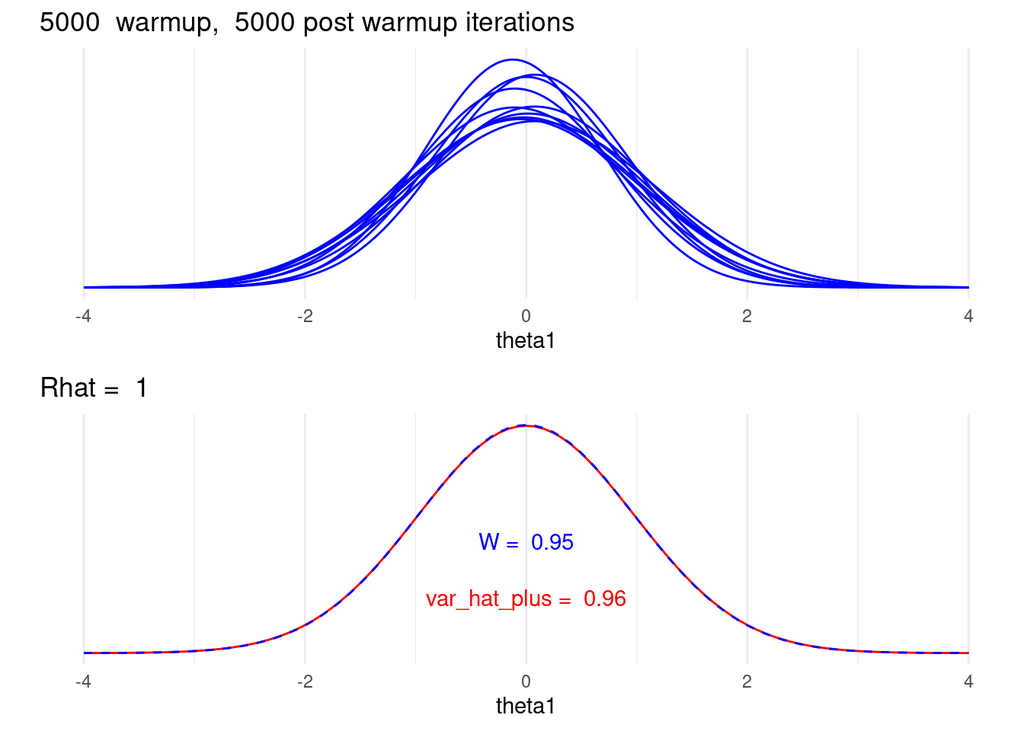

```r
niter <- 10000
plotRhatcomps(dfs2, niter)
```

Plot Rhat with 50% warm-up and increasing number of iterations

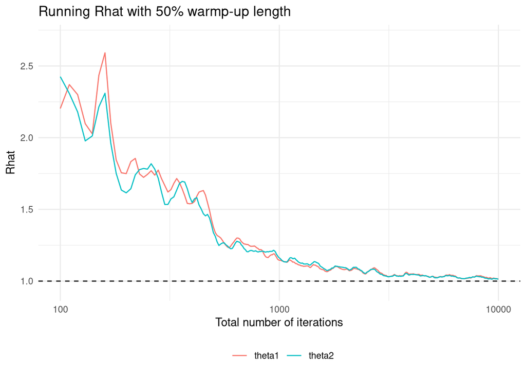

```r
ggplot(data = dfp) +
  geom_line(aes(iter, rhat, color = var)) +
  geom_hline(aes(yintercept = 1), linetype = 'dashed') +
  labs(title = 'Running Rhat with 50% warmp-up length', y = 'Rhat',
       x='Total number of iterations') +
  scale_x_log10(breaks = 10^(2:4), lim = c(100, 10000)) +
  scale_color_discrete(labels = c('theta1','theta2')) +
  theme(legend.position = 'bottom', legend.title = element_blank()) +
  ylim(c(0.95, 2.7))
```

Demonstrate how to compute Rhat (PSRF) using RStan monitor. We need to reorder our array

```r
samp <- aperm(tts, c(1, 3, 2))
monitor(samp, probs = c(0.25, 0.5, 0.75), digits_summary = 2)
```

[output not shown]